# Modelling and Explaining Electricity Prices in Europe

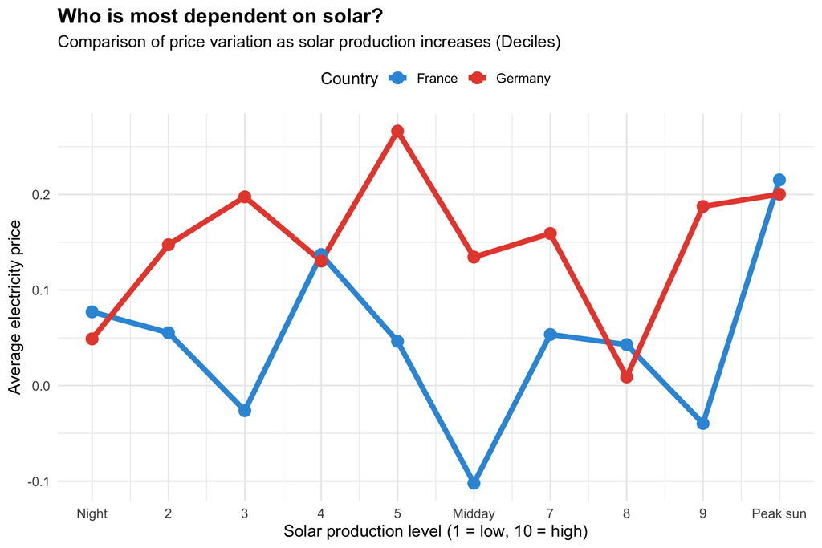

```r
# Create a unified table
df_fr_clean <- df_train %>%
  filter(COUNTRY == "FR") %>%
  select(TARGET, SOLAR = FR_SOLAR) %>%
  mutate(Country = "France")

df_de_clean <- df_train %>%
  filter(COUNTRY == "DE") %>%
  select(TARGET, SOLAR = DE_SOLAR) %>%
  mutate(Country = "Germany")

# Merge
df_compare <- bind_rows(df_fr_clean, df_de_clean)

# Create solar deciles (by country)
df_summary <- df_compare %>%
  group_by(Country) %>%
  mutate(Solar_Bin = ntile(SOLAR, 10)) %>%
  group_by(Country, Solar_Bin) %>%
  summarise(
    Avg_Price = mean(TARGET),
    Price_SE = sd(TARGET) / sqrt(n()),
    .groups = "drop"
  )

# Solar sensitivity chart
ggplot(df_summary, aes(x = Solar_Bin, y = Avg_Price, color = Country, group = Country)) +
  geom_line(linewidth = 2) +
  geom_point(size = 4) +

  scale_color_manual(
    values = c("Germany" = "#E74C3C", "France" = "#3498DB")
  ) +

  scale_x_continuous(
    breaks = 1:10,
    labels = c("Night", "2", "3", "4", "5", "Midday", "7", "8", "9", "Peak sun")
  ) +

  theme_minimal(base_size = 13) +
  labs(
    title = "Who is most dependent on solar?",
    subtitle = "Comparison of price variation as solar production increases (Deciles)",
    x = "Solar production level (1 = low, 10 = high)",
    y = "Average electricity price",
    color = "Country"
  ) +
  theme(
    plot.title = element_text(face = "bold", size = 16),
    legend.position = "top"
  )
```

Following on from the wind analysis, this chart shows that the effect of solar on prices is weaker and less monotonic than that of wind, with greater sensitivity in Germany than in France, but without a comparable structural role to that of wind.

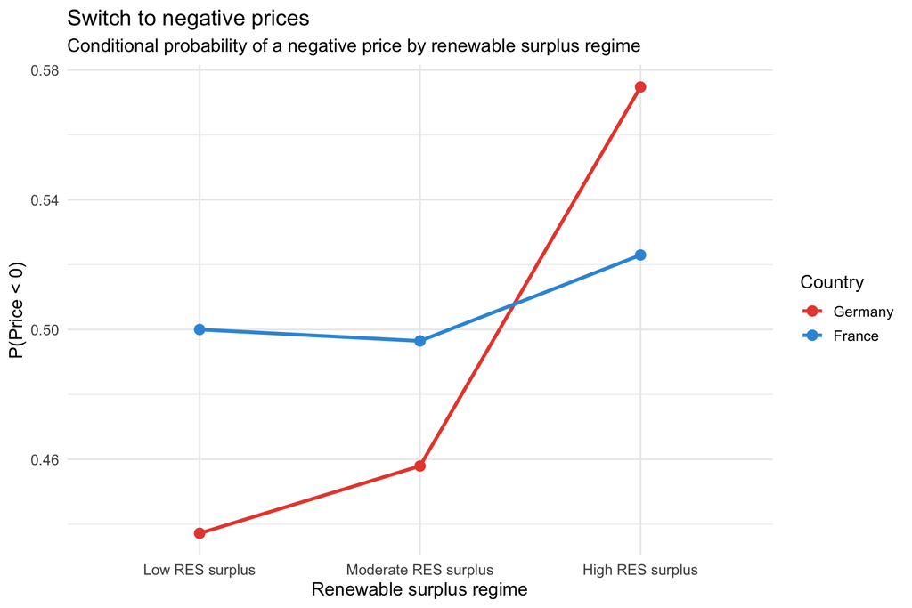

```r
# Creating the renewable surplus indicator
df_neg <- df_train %>%
  mutate(
    renew_ratio = ifelse(
      COUNTRY == "FR",
      (FR_WINDPOW + FR_SOLAR) / FR_CONSUMPTION,
      (DE_WINDPOW + DE_SOLAR) / DE_CONSUMPTION
    ),
    price_negative = TARGET < 0
  )

# Winsorisation (1% - 99%)
q_low  <- quantile(df_neg$renew_ratio, 0.01, na.rm = TRUE)
q_high <- quantile(df_neg$renew_ratio, 0.99, na.rm = TRUE)

df_neg <- df_neg %>%
  mutate(
    renew_ratio_w = pmin(pmax(renew_ratio, q_low), q_high)
  )

# Discretisation into regimes (tertiles)
df_neg <- df_neg %>%
  group_by(COUNTRY) %>%
  mutate(
    renew_regime = ntile(renew_ratio_w, 3),
    renew_regime = factor(
      renew_regime,
      levels = c(1, 2, 3),
      labels = c(
        "Low RES surplus",
        "Moderate RES surplus",
        "High RES surplus"
      )
    )
  ) %>%
  ungroup()


df_neg_summary <- df_neg %>%
  group_by(COUNTRY, renew_regime) %>%
  summarise(
    prob_negative = mean(price_negative),
    n_obs = n(),
    .groups = "drop"
  )


ggplot(df_neg_summary,
       aes(x = renew_regime, y = prob_negative, color = COUNTRY, group = COUNTRY)) +

  geom_line(linewidth = 1.2) +
  geom_point(size = 3) +

  scale_color_manual(
    values = c("FR" = "#3498db", "DE" = "#e74c3c"),
    labels = c("FR" = "France", "DE" = "Germany")
  ) +

  theme_minimal(base_size = 13) +
  labs(
    title = "Switch to negative prices",
    subtitle = "Conditional probability of a negative price by renewable surplus regime",
    x = "Renewable surplus regime",
    y = "P(Price < 0)",
    color = "Country"
  )
```

# 4 Feature Engineering

Raw data is not sufficient to capture the non-linearity of electricity prices (e.g., prices explode exponentially and non-linearly during cold spells). We therefore enriched the dataset with the following variables:

1. **Non-Linear Transformations**: Addition of the square of temperatures (`TEMP^2`) to capture the non-linear effect of heating in winter and air conditioning in summer.
2. **Physical Ratios**: Calculation of the share of renewable energies (`RENEW_RATIO`) which influences the probability of negative prices.
3. **Economic Interactions**: Creation of interaction variables (e.g., `THERMAL_STRESS`) modelling the marginal cost of production. According to the *Merit Order* theory, the price is set by the last plant called upon (often gas or coal).
4. **Temporal Dynamics**: Integration of lag variables ($t-1$, $t-2$, $t-24$) and 24h rolling statistics to capture price inertia and volatility.

```r
df_train <- df_train %>%
  group_by(COUNTRY) %>%
  arrange(DAY_ID) %>%
  mutate(
    target_lag1  = lag(TARGET, 1),
    target_lag2  = lag(TARGET, 2),
    target_lag24 = lag(TARGET, 24),
    roll_mean_24 = zoo::rollmean(TARGET, 24, fill = NA, align = "right"),
    roll_sd_24   = zoo::rollapply(TARGET, 24, sd, fill = NA, align = "right")
  ) %>%
  ungroup()
```

```r
# Feature selection and creation functions for France and Germany
select_features_de <- function(df) {
  df %>% select(TARGET, starts_with("DE_"), GAS_RET, COAL_RET, CARBON_RET,
                target_lag1, target_lag2, target_lag24,
                roll_mean_24, roll_sd_24) %>%
    select(-DE_WIND, -DE_RAIN, -DE_NET_EXPORT, -DE_FR_EXCHANGE)
}

select_features_fr <- function(df) {
  df %>% select(TARGET, starts_with("FR_"), GAS_RET, COAL_RET, CARBON_RET,
                DE_WINDPOW, DE_SOLAR, DE_CONSUMPTION, DE_NET_IMPORT, DE_RESIDUAL_LOAD,
                target_lag1, target_lag2, target_lag24,
                roll_mean_24, roll_sd_24) %>%
    select(-FR_WIND, -FR_RAIN, -FR_NET_EXPORT, -FR_DE_EXCHANGE)
}

# Creation of non-linear variables
add_nonlinear_features <- function(df, country) {
  epsilon <- 1e-5
  if (country == "FR") {
    df <- df %>% mutate(
      FR_TEMP_sq = FR_TEMP^2,
      FR_THERMAL_STRESS = FR_RESIDUAL_LOAD * GAS_RET,
      FR_RENEW_RATIO = (FR_WINDPOW + FR_SOLAR) / (FR_CONSUMPTION + epsilon),
      FR_HEATING_NEED = pmax(0, 15 - FR_TEMP)
    )
  } else {
    df <- df %>% mutate(
      DE_TEMP_sq = DE_TEMP^2,
      DE_THERMAL_STRESS = DE_RESIDUAL_LOAD * COAL_RET,
      DE_RENEW_RATIO = (DE_WINDPOW + DE_SOLAR) / (DE_CONSUMPTION + epsilon)
    )
  }
  return(df)
}

# Pipeline application for France and Germany
train_fr_final <- df_train %>%
  filter(COUNTRY == "FR") %>%
  select_features_fr() %>%
  add_nonlinear_features("FR")

train_de_final <- df_train %>%
  filter(COUNTRY == "DE") %>%
  select_features_de() %>%
  add_nonlinear_features("DE")
```

# 5 Feature Selection

This code defines a cleaning function that optimises the French and German datasets by removing near-zero variance variables and those showing strong multicollinearity. This procedure reduces dimensionality and improves the stability of future training models by retaining only the most relevant predictors.

```r
# Generic cleaning function before training
clean_features_pre_training <- function(df, target_col = "TARGET", corr_thresh = 0.8) {

  cat(paste("--- Cleaning:", deparse(substitute(df)), "---\n"))
  cat("Initial number of variables:", ncol(df), "\n")

  # 1. Separate Target and Features
  y <- df[[target_col]]
  X <- df %>% select(-all_of(target_col))

  # 2. Remove near-zero variance variables (those that never change)
  nzv <- nearZeroVar(X)
  if (length(nzv) > 0) {
    cat("Near-zero variance variables removed:", names(X)[nzv], "\n")
    X <- X[, -nzv]
  }

  # 3. Remove Multicollinearity (Redundancy between features)
  # Compute the correlation matrix between explanatory variables only
  corr_mat <- cor(X, use = "pairwise.complete.obs", method = "spearman")

  # findCorrelation returns the indices of columns to remove
  high_corr_idx <- findCorrelation(corr_mat, cutoff = corr_thresh)

  if (length(high_corr_idx) > 0) {
    removed_vars <- names(X)[high_corr_idx]
    cat("Highly correlated variables removed (>", corr_thresh, "):\n")
    print(removed_vars)
    X <- X[, -high_corr_idx]
  }

  # 4. Reconstruct the clean DataFrame
  df_clean <- bind_cols(X, TARGET = y)

  cat("Final number of variables:", ncol(df_clean), "\n\n")
  return(df_clean)
}

# --- APPLICATION TO BOTH COUNTRIES ---
train_fr_selected <- clean_features_pre_training(train_fr_final, corr_thresh = 0.80)
```

```
## --- Cleaning: train_fr_final ---
## Initial number of variables: 28
## Highly correlated variables removed (> 0.8 ):
## [1] "FR_CONSUMPTION"   "FR_RESIDUAL_LOAD" "DE_SOLAR"         "FR_HEATING_NEED"
## Final number of variables: 24
```

```r
train_de_selected <- clean_features_pre_training(train_de_final, corr_thresh = 0.80)
```

```
## --- Cleaning: train_de_final ---
## Initial number of variables: 23
## Final number of variables: 23
```